# Forecasting Electricity Demand in the NEM

# Project Overview

This project develops time series forecasting models for hourly electricity demand in Victoria’s National Electricity Market.

## Import Libraries

```r
library(dplyr)
library(stringr)
library(fpp3)
library(lubridate)
library(janitor)
library(forecast)
library(hexbin)
library(ggplot2)
```

## Import Dataset

Monthly AEMO price and demand files are imported and combined into a single dataframe. The number of inputs files is checked before concatenating the monthly datasets into a single table.

```r
files <- sort(
  list.files(
    path = "Price_and_demand",
    pattern = "PRICE_AND_DEMAND_.*_VIC1.*",
    full.names = TRUE
  )
)

n_files <- length(files)

df <- files |>  lapply(read.csv) |>  bind_rows()
```

## Data Cleaning and Validation

The raw AEMO price and demand data were cleaned and transformed prior to analysis. Records were sorted chronologically and filtered to retain only trading interval observations. Key variables were renamed to improve readability, and timestamps were converted to a datetime format suitable for time series analysis.

Duplicate timestamps were checked to ensure data integrity. The data were then aggregated from trading intervals to hourly observations by calculating the average demand and wholesale electricity price within each hour.

To verify completeness, an expected sequence of hourly timestamps was generated and compared against the observed timestamps to identify any missing periods. Finally, summary statistics and dataset dimensions were reviewed to validate the cleaned dataset.

```r
df <- df |>
  arrange(SETTLEMENTDATE) |>
  filter(PERIODTYPE == "TRADE") |>
  rename(datetime = SETTLEMENTDATE,
         demand_mw = TOTALDEMAND,
         price_aud_mwh = RRP
         )

df <- df |>
  mutate(
    datetime = lubridate::ymd_hms(datetime)
  )

dupes <- sum(duplicated(df$datetime))

df_hourly <- df |>
  mutate(datetime = floor_date(datetime, "hour")) |>
  group_by(datetime) |>
  summarise(
    demand_mw = mean(demand_mw, na.rm = TRUE),
    price_aud_mwh = mean(price_aud_mwh, na.rm = TRUE),
    .groups = "drop")

expected_hours <- seq(
  min(df_hourly$datetime),
  max(df_hourly$datetime),
  by = "hour"
)

missing_hours <- setdiff(expected_hours,
                         df_hourly$datetime)


glimpse(df_hourly)
```

```
Rows: 37,225
Columns: 3
$ datetime      <dttm> 2022-01-01 00:00:00, 2022-01-01 01:00:00, 2022-01-01 02…
$ demand_mw     <dbl> 4813.945, 4445.696, 4147.942, 3949.367, 3938.868, 3912.6…
$ price_aud_mwh <dbl> 109.10545, 85.57833, 84.57000, 64.61417, 54.81250, 40.78…
```

```r
summary(df_hourly)
```

```
    datetime                     demand_mw     price_aud_mwh
 Min.   :2022-01-01 00:00:00   Min.   : 1276   Min.   : -601.698
 1st Qu.:2023-01-23 18:00:00   1st Qu.: 4083   1st Qu.:    6.855
 Median :2024-02-15 12:00:00   Median : 4653   Median :   65.957
 Mean   :2024-02-15 12:00:00   Mean   : 4768   Mean   :   84.625
 3rd Qu.:2025-03-09 06:00:00   3rd Qu.: 5381   3rd Qu.:  125.286
 Max.   :2026-04-01 00:00:00   Max.   :10506   Max.   :16600.000
```

```r
nrow(df_hourly)
```

```
[1] 37225
```

## Data Exploration

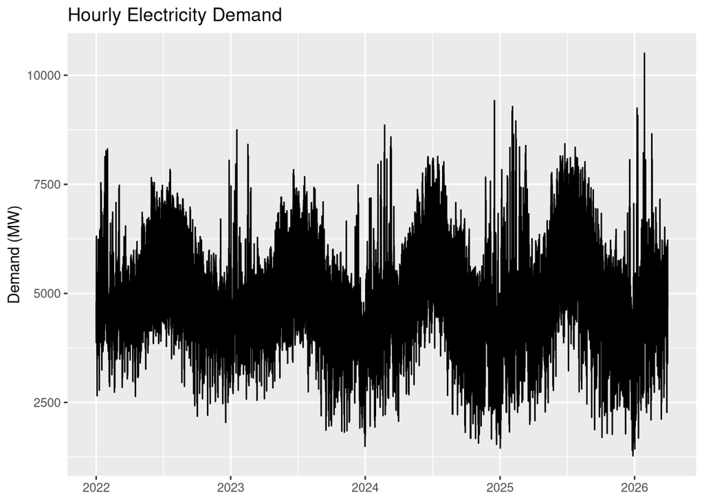

```r
ggplot(df_hourly,
       aes(datetime, demand_mw)) +
  geom_line() +
  labs(
    title = "Hourly Electricity Demand",
    x = NULL,
    y = "Demand (MW)"
  )
```

The hourly demand series is plotted to identify long-term trends and seasonal behaviour. Demand exhibits clear seasonality and substantial short-term variation. Seasonal fluctuations dominate the series, with variation in the underlying trend over time.

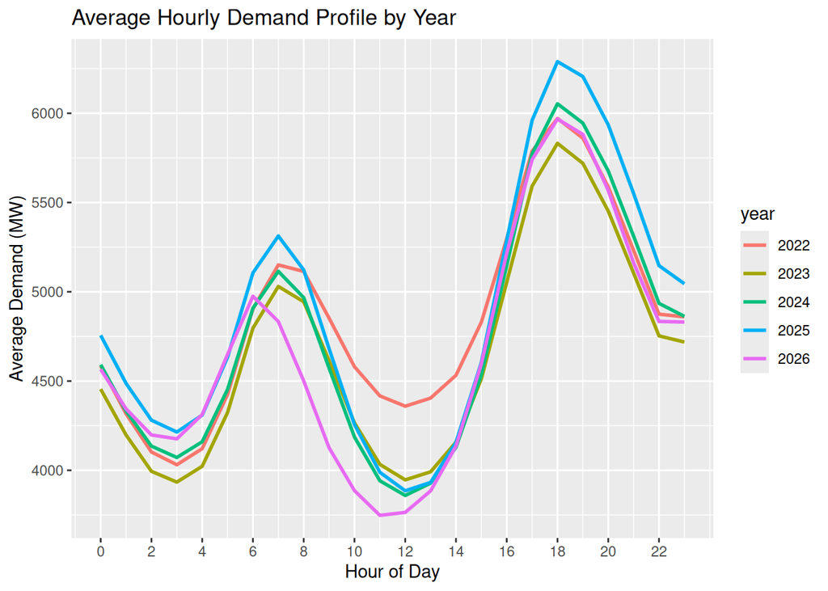

```r
df_hourly |>
  mutate(
    year = factor(year(datetime)),
    hour = hour(datetime)
  ) |>
  group_by(year, hour) |>
  summarise(
    avg_demand = mean(demand_mw),
    .groups = "drop"
  ) |>
  ggplot(aes(hour, avg_demand, colour = year)) +
  geom_line(linewidth = 1) +
  labs(
    title = "Average Hourly Demand Profile by Year",
    x = "Hour of Day",
    y = "Average Demand (MW)"
  ) +
  scale_x_continuous(breaks = seq(0, 23, 2))
```

Demand in 2025 is generally higher throughout the day and exhibits the largest evening peak, whereas demand in 2023 and 2026 is comparatively lower.

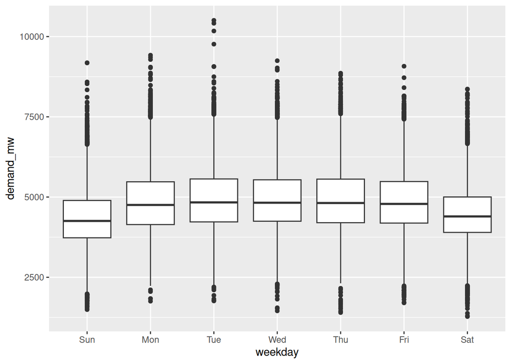

```r
df_hourly |>
  mutate(
    weekday = wday(
      datetime,
      label = TRUE
    )
  ) |>
  ggplot(aes(weekday, demand_mw)) +
  geom_boxplot()
```

Electricity demand varies systematically throughout the week. Median demand is lowest on weekends, particularly on Sunday, and highest during weekdays. Tuesday to Thursday exhibit the greatest median demand levels, while Saturday and Sunday show reduced consumption.

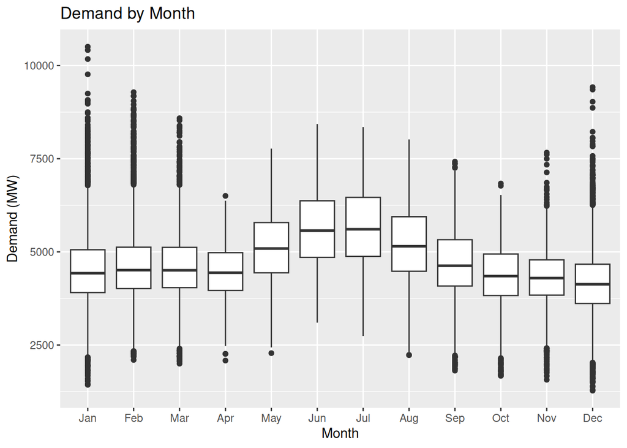

```r
df_hourly |>
  mutate(
    month = month(datetime, label = TRUE)
  ) |>
  ggplot(aes(month, demand_mw)) +
  geom_boxplot() +
  labs(
    title = "Demand by Month",
    x = "Month",
    y = "Demand (MW)"
  )
```

Electricity demand exhibits clear seasonal variation throughout the year. Median demand is highest during the winter months, particularly June and July, where demand frequently exceeds 5,500 MW. In contrast, demand is generally lower during spring and late summer, with October to December exhibiting the lowest median demand levels.

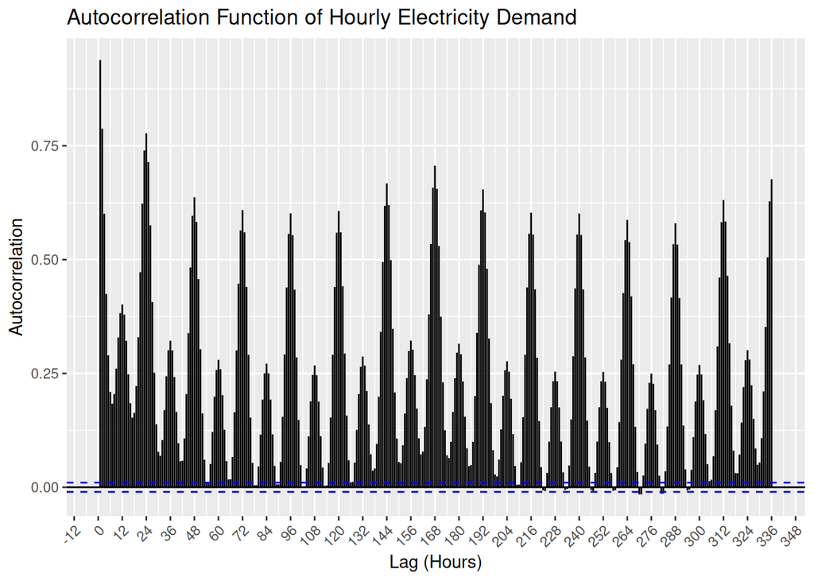

```r
elec <- df_hourly |>
  as_tsibble(index = datetime)

elec |>
  ACF(demand_mw, lag_max = 24 * 14) |>
  autoplot() +
  labs(
    title = "Autocorrelation Function of Hourly Electricity Demand",
    x = "Lag (Hours)",
    y = "Autocorrelation"
  ) +
  theme(
    axis.text.x = element_text(
      angle = 45,
      hjust = 1
    )
  )
```

The autocorrelation function reveals strong temporal dependence in hourly electricity demand. Autocorrelation is highest at short lags, indicating that demand in a given hour is strongly related to demand in preceding hours. Pronounced spikes occur at regular 24-hour intervals (24, 48, 72 hours and so on), demonstrating strong daily seasonality. Additional peaks are visible at 168 and 336 hours, corresponding to one and two weeks respectively, confirming the presence of weekly seasonal patterns. The recurrence of these peaks suggests that demand profiles are highly predictable from previous days and weeks.

Almost all autocorrelation coefficients remain above the significance bounds, indicating that historical demand contains substantial predictive information. The strong daily and weekly seasonal structure observed in the ACF supports the use of seasonal forecasting models such as Seasonal Naive, ETS and ARIMA, which can account for these recurring patterns.

## Forecasting

To identify an appropriate benchmark model, seasonal naive forecasts were evaluated using time series cross-validation. Given the strong seasonal patterns observed during the exploratory analysis, models based on daily, weekly and yearly lags were compared.

### Seasonal Naive Cross-Validation

A rolling-origin cross-validation approach was used with an initial training window of 2 years, expanded by one week at each iteration. Forecast accuracy was assessed over a 1 week prediction horizon. The seasonal naive model generate forecasts by repeating observations from the corresponding period in the previous seasonal cycle:

$$\hat{y}_{t+h|t} = y_{t+h-m}$$

where $\hat{y}_{t+h|t}$ is the forecast made at time $t$ for horizon $h$, and $m$ is the seasonal period.

```r
elec_cv <- elec |>
  filter(datetime <= max(datetime) - days(14)) |>
  stretch_tsibble(.init = 24*365*2, .step = 24 * 7)

fc_cv <- elec_cv |>
  model(
    day = SNAIVE(demand_mw ~ lag("day")),
    week = SNAIVE(demand_mw ~ lag("week")),
    year = SNAIVE(demand_mw ~ lag("year"))
  ) |>
  forecast(h = 24*7)

fc_cv |>
  accuracy(elec)
```

```
# A tibble: 3 × 10
  .model .type    ME  RMSE   MAE   MPE  MAPE  MASE RMSSE  ACF1
  <chr>  <chr> <dbl> <dbl> <dbl> <dbl> <dbl> <dbl> <dbl> <dbl>
1 day    Test  427.  1015.  735.  7.08  15.8  1.54  1.43 0.948
2 week   Test   11.7  913.  606. -1.89  13.7  1.27  1.29 0.960
3 year   Test  104.  1538. 1230. -3.65  26.5  2.58  2.17 0.912
```

Seasonal naive models using daily, weekly and yearly lags were compared using time series cross-validation. The weekly seasonal naive model achieved the best accuracy, outperforming both the daily and yearly alternatives. This finding suggests that electricity demand is more closely related to demand observed during the same hour of the previous week than the previous day or year. Consequently, the weekly seasonal naive model was selected as the benchmark for subsequent comparisons with ETS and ARIMA models.

## Comparison with ETS And ARIMA models

Following the evaluation of seasonal naive benchmark models, more advanced forecasting approaches were considered. Exponential Smoothing State Space (ETS) and AutoRegressive Integrated Moving Average (ARIMA) models were fitted and compared against the seasonal naive benchmark.

To evaluate forecast performance, the data were divided into training and test sets. The most recent two weeks of observations were reserved as a holdout test set, while the preceding two years of data were used for model estimation. Cross-validation was not used due to memory constraints.

### ETS Model:

$$y_t = \ell_{t-1} + S_{t-m} + \varepsilon_t$$

where:

$\ell_{t-1}$ is the level component,

$S_{t-m}$ is the seasonal component,

$m$ is the seasonal period, and

$\varepsilon_t$ is the error term.

### General ARIMA model:

$$\phi(B)(1-B)^d y_t = \theta(B)\varepsilon_t$$

where:

$B$ is the backshift operator,

$d$ is the order of differencing,

$\phi(B)$ ist he autoregressive polynomial,

$\theta(B)$ is the moving-average polynomial.

```r
forecast_horizon <- weeks(2)

test_start <- max(elec$datetime) - forecast_horizon

train_start <- test_start - years(2)

train <- elec |>
  filter(
    datetime >= train_start,
    datetime < test_start
  )

test <- elec |>
  filter(datetime >= test_start)

fit <- train |>
  model(
    day   = SNAIVE(demand_mw ~ lag("day")),
    week   = SNAIVE(demand_mw ~ lag("week")),
    ets   = ETS(demand_mw),
    arima = ARIMA(demand_mw)
  )
fc <- fit |>
  forecast(new_data = test)
```

We compare forecast accuracy and find that the the week model performed best overall, achieving the lowest RMSE (599.4) and MAPE (9.57%), indicating the most accurate forecasts overall. The ETS model produced slightly poorer results across all metrics, while ARIMA had the lowest MAE (409.7) but the highest errors in terms of RMSE and MAPE compared with the other top-performing models. The day model performed worst on all measures.

```r
acc <- accuracy(fc, test)

acc |>
  select(
    .model,
    RMSE,
    MAE,
    MAPE
  ) |>
  arrange(RMSE)
```

```
# A tibble: 4 × 4
  .model  RMSE   MAE  MAPE
  <chr>  <dbl> <dbl> <dbl>
1 week    599.  417.  9.57
2 ets     619.  464.  9.71
3 arima   642.  410. 10.5
4 day     750.  513. 13.0
```

## Plotting forecasts

Forecasts from the week, ETS and ARIMA models were plotted against the observed demand in the test period, with the final two weeks of training data included for context. The plots allow a visual comparison of how closely each model’s forecasts align with actual demand following the forecast start date, helping to assess forecast accuracy and identify any systematic over- or under-prediction.

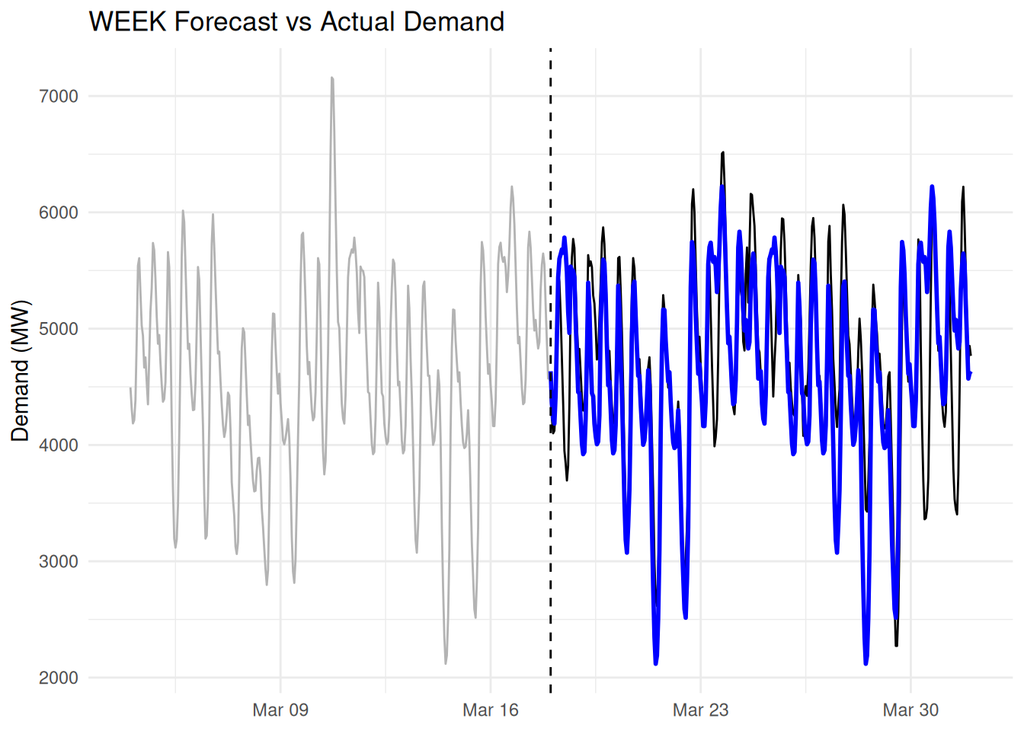

```r
plot_forecast <- function(model_name,
                          forecast_obj,
                          train_data,
                          test_data,
                          test_start,
                          colour = "red") {

  fc_model <- forecast_obj |>
    filter(.model == model_name) |>
    as_tibble() |>
    arrange(datetime)

  ggplot() +

    geom_line(
      data = filter(
        train_data,
        datetime >= test_start - weeks(2)
      ),
      aes(datetime, demand_mw),
      colour = "grey70"
    ) +

    geom_line(
      data = test_data,
      aes(datetime, demand_mw),
      colour = "black"
    ) +

    geom_line(
      data = fc_model,
      aes(datetime, .mean),
      colour = colour,
      linewidth = 1
    ) +

    geom_vline(
      xintercept = test_start,
      linetype = "dashed"
    ) +

    labs(
      title = paste(
        toupper(model_name),
        "Forecast vs Actual Demand"
      ),
      x = NULL,
      y = "Demand (MW)"
    ) +

    theme_minimal()
}

plot_forecast(
  "week",
  fc,
  train,
  test,
  test_start,
  "blue"
)
```

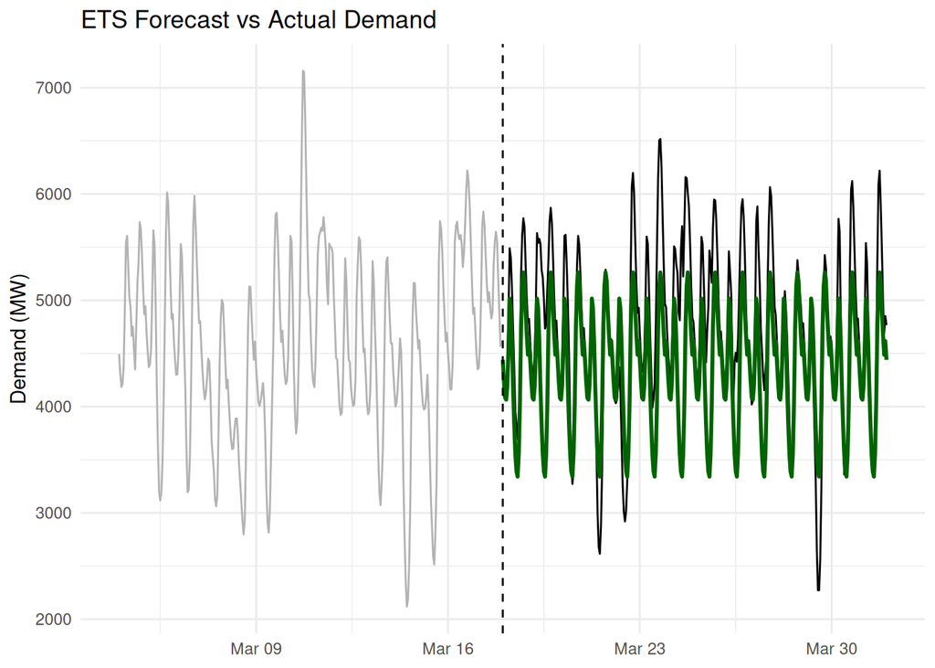

```r
plot_forecast(
  "ets",
  fc,
  train,
  test,
  test_start,
  "darkgreen"
)
```

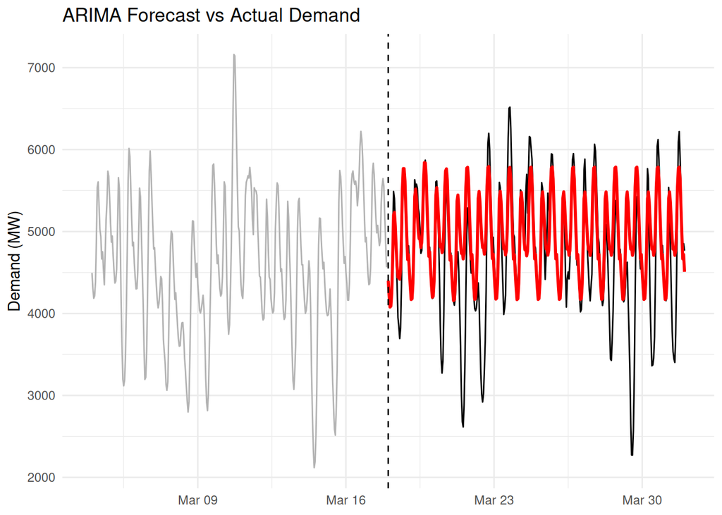

```r
plot_forecast(
  "arima",
  fc,
  train,
  test,
  test_start,
  "red"
)
```

## Conclusion

This project developed and evaluated forecasting models for hourly electricity demand in Victoria’s National Electricity Market. Exploratory analysis revealed strong daily and weekly seasonal patterns, which were confirmed through autocorrelation analysis.

Seasonal naive benchmark models were compared using time series cross-validation, with the weekly seasonal naive model providing the strongest benchmark performance.

When compared against ETS and ARIMA models on a two-week holdout sample, the weekly seasonal naive model achieved the lowest RMSE and MAPE, indicating the best overall forecast accuracy. This suggests that electricity demand is highly dependent on demand observed during the corresponding hour of the previous week.

Future work could incorporate exogenous predictors such as temperature, weather conditions, public holidays and economic activity to improve forecast performance.